# Predicting Breast Cancer Outcomes from Clinical Features and Protein Biomarkers

# 5) ANOVA: Protein biomarkers across clinical groups

```r
# identify protein biomarker columns (protein1–protein4)
protein_vars <- names(brca)[grepl("^protein", names(brca))]
```

##### Do protein levels differ by tumour stage?

```r
# group means by tumour_stage
means_tumour_stage <- brca |>
  select(tumour_stage, all_of(protein_vars)) |>
  pivot_longer(
    cols = all_of(protein_vars),
    names_to = "biomarker",
    values_to = "value"
  ) |>
  group_by(tumour_stage, biomarker) |>
  summarise(
    mean_value = mean(value, na.rm = TRUE),
    n = sum(!is.na(value)),
    .groups = "drop"
  )

# one-way ANOVA for each protein ~ tumour_stage
anova_tumour_stage <- protein_vars |>
  lapply(function(p) {
    fit <- aov(reformulate("tumour_stage", response = p), data = brca)
    tidy(fit) |>
      slice(1) |>
      transmute(
        biomarker = p,
        df = df,
        f_statistic = statistic,
        p_value = p.value
      )
  }) |>
  bind_rows() |>
  mutate(p_adj = p.adjust(p_value, method = "BH"))

means_tumour_stage
```

```
## # A tibble: 12 × 4
##    tumour_stage biomarker mean_value     n
##    <ord>        <chr>          <dbl> <int>
##  1 I            protein1    -0.0144     64
##  2 I            protein2     1.00       64
##  3 I            protein3    -0.165      64
##  4 I            protein4     0.0378     64
##  5 II           protein1    -0.00773   189
##  6 II           protein2     0.965     189
##  7 II           protein3    -0.0654    189
##  8 II           protein4     0.0180    189
##  9 III          protein1    -0.0942     81
## 10 III          protein2     0.862      81
## 11 III          protein3    -0.0888     81
## 12 III          protein4    -0.0315     81
```

```r
anova_tumour_stage
```

```
## # A tibble: 4 × 5
##   biomarker    df f_statistic p_value p_adj
##   <chr>     <dbl>       <dbl>   <dbl> <dbl>
## 1 protein1      2       0.697   0.499 0.777
## 2 protein2      2       0.498   0.608 0.777
## 3 protein3      2       0.693   0.501 0.777
## 4 protein4      2       0.253   0.777 0.777
```

For all four proteins (protein1–protein4), the global ANOVA tests were not statistically significant (all BH-adjusted p-values > 0.77). Thus, there is no statistical evidence of differences in biomarker expression by tumour stage in this cohort, and post-hoc pairwise comparisons were not pursued. Although small numerical differences in mean protein levels were observed, these differences were not statistically significant. This suggests that, in this dataset, tumour stage alone does not explain variation in protein biomarker expression. This could be due to biological similarity across stages, high within-group variability, or limited power for detecting subtle effects.

##### Do protein levels differ by histology?

```r
# group means by histology
means_histology <- brca |>
  select(histology, all_of(protein_vars)) |>
  pivot_longer(
    cols = all_of(protein_vars),
    names_to = "biomarker",
    values_to = "value"
  ) |>
  group_by(histology, biomarker) |>
  summarise(
    mean_value = mean(value, na.rm = TRUE),
    n = sum(!is.na(value)),
    .groups = "drop"
  )

# one-way ANOVA for each protein ~ histology
anova_histology <- protein_vars |>
  lapply(function(p) {
    fit <- aov(reformulate("histology", response = p), data = brca)
    tidy(fit) |>
      slice(1) |>
      transmute(
        biomarker = p,
        df = df,
        f_statistic = statistic,
        p_value = p.value
      )
  }) |>
  bind_rows() |>
  mutate(p_adj = p.adjust(p_value, method = "BH"))

means_histology
```

```
## # A tibble: 12 × 4
##    histology                      biomarker mean_value     n
##    <fct>                          <chr>          <dbl> <int>
##  1 Infiltrating Ductal Carcinoma  protein1    -0.0500    233
##  2 Infiltrating Ductal Carcinoma  protein2     0.930     233
##  3 Infiltrating Ductal Carcinoma  protein3    -0.0804    233
##  4 Infiltrating Ductal Carcinoma  protein4     0.00905   233
##  5 Infiltrating Lobular Carcinoma protein1    -0.00522    89
##  6 Infiltrating Lobular Carcinoma protein2     1.03       89
##  7 Infiltrating Lobular Carcinoma protein3    -0.139      89
##  8 Infiltrating Lobular Carcinoma protein4    -0.00825    89
##  9 Mucinous Carcinoma             protein1     0.174      12
## 10 Mucinous Carcinoma             protein2     0.684      12
## 11 Mucinous Carcinoma             protein3     0.0840     12
## 12 Mucinous Carcinoma             protein4     0.159      12
```

```r
anova_histology
```

```
## # A tibble: 4 × 5
##   biomarker    df f_statistic p_value p_adj
##   <chr>     <dbl>       <dbl>   <dbl> <dbl>
## 1 protein1      2       1.02    0.362 0.557
## 2 protein2      2       0.887   0.413 0.557
## 3 protein3      2       0.876   0.417 0.557
## 4 protein4      2       0.372   0.690 0.690
```

Across histologic subtypes, protein levels were visually and statistically similar, with substantial overlap between groups. All BH-adjusted ANOVA p-values were > 0.36, indicating no detectable expression differences by histology. Consequently, post-hoc pairwise comparisons were not performed.

Because no p-values are statistically significant, we check ANOVA assumptions!

##### Normality (per group per protein)

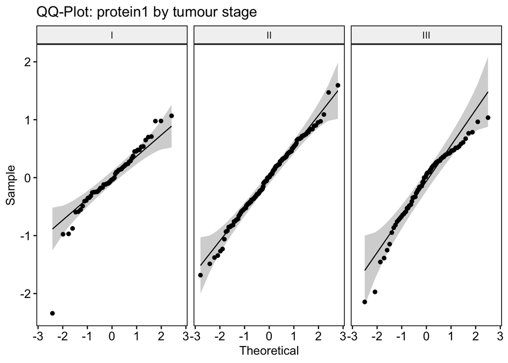

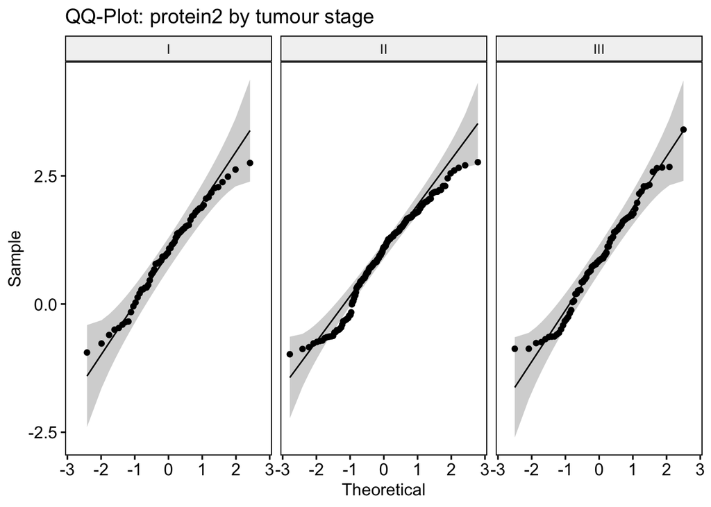

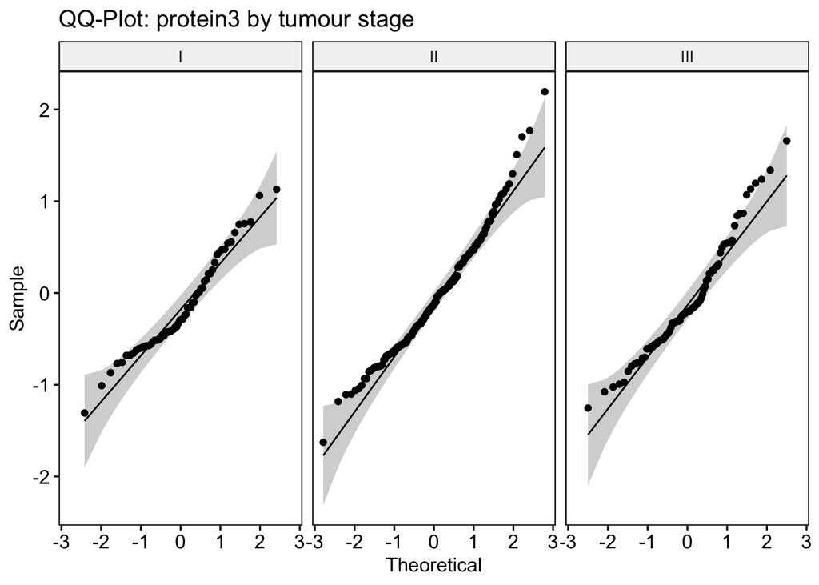

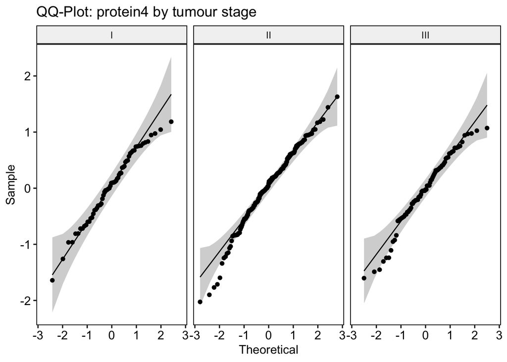

```r
for (p in protein_vars) {
print(
ggqqplot(brca, x = p, facet.by = "tumour_stage",
title = paste("QQ-Plot:", p, "by tumour stage"))
)
}
```

The QQ-plots for each protein by tumour stage were reasonably linear, suggesting that the normality assumption is acceptable for these ANOVA models.